# Indicator Profiles

- Show All Code
- Hide All Code
- View Source

# Data Import

Indicator profile probabilities/means and paired-comparison significance tests across the latent class solution are read in from a local Excel results workbook from saved LatentGOLD results. Import code is included but not rendered below.

# Wrangle Profile Data

```r
# Legend labels with cluster size in parentheses
cluster_sizes <- c("C1" = 35.6, "C2" = 33.7, "C3" = 15.8, "C4" = 14.9)

cluster_labels <- c(
  "C1"      = paste0("C1 (", cluster_sizes["C1"], "%)"),
  "C2"      = paste0("C2 (", cluster_sizes["C2"], "%)"),
  "C3"      = paste0("C3 (", cluster_sizes["C3"], "%)"),
  "C4"      = paste0("C4 (", cluster_sizes["C4"], "%)")
)

# Fill colors — no outlines
indicator_colors <- cluster_colors

# Scale factor: right axis max / left axis max (continuous max ~3, binary max 1)
# Continuous values are divided by this before plotting, then right axis
# multiplies back to show true scale. Edit here if any continuous value > 3.
scale_factor <- 3

# Continuous indicators — values can exceed 1 and read off the right axis
continuous_indicators <- c(
  "Problems from alcohol",
  "Sport Teams",
  "Extracurriculars",
  "Don't avoid problems"
)

# Negative panel: binary on left (0-1), continuous on right (0-3)
#   → continuous values divided by scale_factor to fit primary axis
# Positive panel: continuous on left (0-3), binary on right (0-1)
#   → binary values multiplied by scale_factor to fit primary axis
# This arrangement puts the 0-3 axes adjacent in the middle of the combined figure.

neg_continuous <- c("Problems from alcohol")
pos_continuous <- c("Sport Teams", "Extracurriculars", "Don't avoid problems")

profile_long <- profile_raw %>%
  pivot_longer(
    cols      = c(Cluster1, Cluster2, Cluster3, Cluster4),
    names_to  = "cluster_raw",
    values_to = "value"
  ) %>%
  mutate(
    cluster    = recode(cluster_raw,
                   "Cluster1" = "C1", "Cluster2" = "C2",
                   "Cluster3" = "C3", "Cluster4" = "C4"),
    cluster    = factor(cluster, levels = c("C1", "C2", "C3", "C4")),
    Indicators = factor(Indicators, levels = unique(profile_raw$Indicators)),
    # Rescale for plotting:
    #   Negative: continuous / scale_factor (plots on 0-1 axis, reads off right 0-3)
    #   Positive: binary * scale_factor     (plots on 0-3 axis, reads off right 0-1)
    value_plot = case_when(
      Risk == "Negative" & Indicators %in% neg_continuous ~ value / scale_factor,
      Risk == "Positive" & !Indicators %in% pos_continuous ~ value * scale_factor,
      TRUE ~ value
    )
  )
```

# BH Correction on Pairwise Comparisons

Non-estimable rows (p = “.”) and the Intercept block are dropped before correction is applied across all remaining tests simultaneously.

```r
pairs <- pairs_raw %>%
  filter(Indicator != "Intercept", `p-value` != ".") %>%
  mutate(
    p_value   = as.numeric(`p-value`),
    cluster_a = as.integer(clustera),
    cluster_b = as.integer(clusterb),
    pair      = paste0("C", cluster_a, " vs. C", cluster_b),
    p_adj     = p.adjust(p_value, method = "BH"),
    sig       = p_adj < .05
  )
```

# Profile Figure

Figure 1: Negative Indicators Left y-axis (0–1): binary indicators, read as probabilities. Right y-axis (0–3): continuous indicators, read as means.

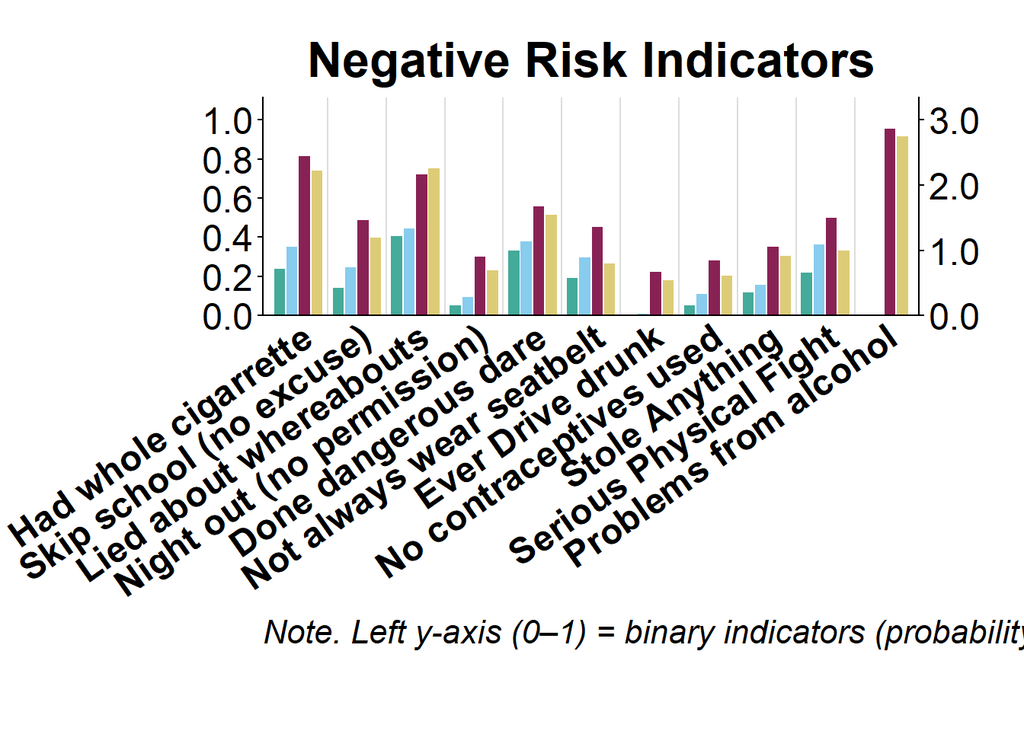

Figure 1

```r
fig_caption <- paste(
  "Note. Left y-axis (0\u20131) = binary indicators (probability of behavior).",
  "Right y-axis (0\u20133) = continuous indicators (within-class mean).",
  "Continuous bars are rescaled to the primary axis for display;"
)

# make_panel() takes explicit axis config so Negative and Positive can differ.
#
# Negative: left = binary 0-1, right = continuous 0-3
#   primary axis shows 0-1; sec.axis multiplies by scale_factor to show 0-3
#
# Positive: left = continuous 0-3, right = binary 0-1
#   primary axis shows 0-3; sec.axis divides by scale_factor to show 0-1

make_panel <- function(risk_label,
                       left_name = "" ,left_lim, left_breaks,
                       sec_transform, right_name = "", right_breaks) {

  df <- profile_long %>% filter(Risk == risk_label)

  ggplot(df, aes(x = Indicators, y = value_plot, fill = cluster)) +
     geom_vline(
  xintercept = seq(1.5, length(unique(df$Indicators)) - 0.5, by = 1),
  color      = "#DDDDDD",
  linewidth  = 0.4
) +
    geom_col(
      position = position_dodge(width = dodge_width),
      width    = bar_width
    ) +
    scale_fill_manual(values = indicator_colors, labels = cluster_labels,
                      name = NULL) +
    scale_y_continuous(
      #name   = left_name,
      limits = left_lim,
      breaks = left_breaks,
      labels = number_format(accuracy = 0.1),
      expand = expansion(mult = c(0, 0.03)),
      sec.axis = sec_axis(
        transform = sec_transform,
        name      = right_name,
        breaks    = right_breaks,
        labels    = number_format(accuracy = 0.1)
      )
    ) +
    labs(title = paste(risk_label, "Risk Indicators"), y = NULL, caption = fig_caption) +
    base_theme +
    theme(
      axis.text.x        = element_text(angle = 35, hjust = 1,
                                        size = axis_text_size),
      axis.title.y.right = element_text(size = axis_title_size,
                                        color = "gray40"),
      legend.position    = "none",
      plot.title         = element_text(size = title_size, face = "bold",
                                        hjust = 0.5),
          plot.margin       = margin(20, 0, 40, 100)
    )
}

# Negative: left=binary(0-1), right=continuous(0-3)
p_neg <- make_panel(
  risk_label    = "Negative",
  #left_name     = "Probability (binary indicators)",
  left_lim      = c(0, 1.08),
  left_breaks   = seq(0, 1, by = 0.2),
  sec_transform = ~ . * scale_factor,
 # right_name    = "Within-class mean (continuous indicators)",
  right_breaks  = seq(0, scale_factor, by = 1)
)

# Positive: left=continuous(0-3), right=binary(0-1)
p_pos <- make_panel(
  risk_label    = "Positive",
 # left_name     = "Within-class mean (continuous indicators)",
  left_lim      = c(0, scale_factor * 1.08),
  left_breaks   = seq(0, scale_factor, by = 1),
  sec_transform = ~ . / scale_factor,
 # right_name    = "Probability (binary indicators)",
  right_breaks  = seq(0, 1, by = 0.2)
)

print(p_neg)


ggsave(
  filename = file.path(fig_indicator, "profile_figure_neg.png"),
     device = agg_png,
  plot     = p_neg,
  width    = 14, height = 6, dpi = fig_dpi, units = "in"
)
```

Figure 2: Positive Indicators Left y-axis (0–3): continuous indicators, read as means. Right y-axis (0–1): binary indicators, read as probabilities.

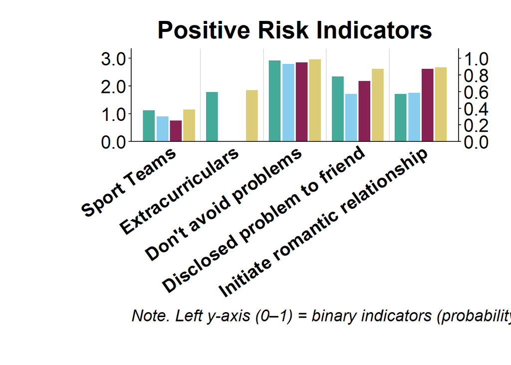

Figure 2

```r
print(p_pos)
ggsave(
  filename = file.path(fig_indicator, "profile_figure_pos.png"),
  plot     = p_pos,
  device = agg_png,
  width    = 14, height = 6, dpi = fig_dpi, units = "in"
)
```

Figure 3: Profiles The two panels (Negative risk / Positive risk) share dual-axis and are combined into one figure.

[figure not shown]

Figure 3

```r
# Remove left axis from positive panel
# so the shared 0-3 middle axis appears only once
p_neg_trim <- p_neg +
  theme(
    axis.text.y.right = element_text(margin = margin(l = 12)),
    plot.margin       = margin(12, 0, 20, 85)
  )
p_pos_trim <- p_pos +
  theme(
    axis.title.y.left = element_blank(),
    axis.text.y.left  = element_blank(),
   # axis.ticks.y.left = element_blank(),
    plot.margin       = margin(12, 12, 12, 0)    # no left margin only
  )
combined <- (p_neg_trim + p_pos_trim) +
  plot_layout(guides = "collect") &
  theme(legend.position = "none")
combined

ggsave(
  filename = file.path(fig_indicator, "profile_figures_combined.png"),
  plot     = combined,
  width    = 40, height = 6, dpi = fig_dpi, units = "in"
)
```

# Table: Non-Significant Comparisons

Table 1: List of non-significant pairwise comparisons

```r
nonsig <- pairs %>%
  filter(sig == FALSE) %>%
  select(Indicator, pair, p_value, p_adj) %>%
  mutate(across(c(p_value, p_adj), ~ round(.x, 3))) %>%
  arrange(Indicator, pair)

kable(nonsig,
      col.names = c("Indicator", "Comparison", "Raw p", "BH-adjusted p"),
      caption   = "Non-significant pairwise comparisons after Benjamini-Hochberg correction (FDR < .05).")
```

Table 1: Non-significant pairwise comparisons after Benjamini-Hochberg correction (FDR < .05).

| Indicator | Comparison | Raw p | BH-adjusted p |
| --- | --- | --- | --- |
| WSDactivity | C1 vs. C4 | 0.170 | 0.186 |
| WSDalc | C3 vs. C4 | 0.300 | 0.317 |
| WSDsport | C1 vs. C4 | 0.630 | 0.630 |
| avoidproblems | C1 vs. C3 | 0.170 | 0.186 |
| avoidproblems | C1 vs. C4 | 0.380 | 0.388 |
| avoidproblems | C2 vs. C3 | 0.350 | 0.362 |
| avoidproblems | C3 vs. C4 | 0.073 | 0.086 |
| dare_dum | C3 vs. C4 | 0.170 | 0.186 |
| drvdrunk | C3 vs. C4 | 0.085 | 0.099 |
| intitaterelationship | C1 vs. C2 | 0.500 | 0.505 |
| intitaterelationship | C3 vs. C4 | 0.330 | 0.345 |
| liewhere | C1 vs. C2 | 0.051 | 0.061 |
| liewhere | C3 vs. C4 | 0.290 | 0.310 |
| phyfight | C2 vs. C4 | 0.260 | 0.281 |
| seatbelt | C2 vs. C4 | 0.160 | 0.181 |
| steal12M | C3 vs. C4 | 0.150 | 0.172 |

# Significant Comparisons by Profile

Table 2: Total Significant Pairwise Comparisons by Cluster

```r
sig_pairs <- pairs %>% filter(sig == TRUE)

by_cluster <- bind_rows(
  sig_pairs %>% select(cluster = cluster_a, Indicator),
  sig_pairs %>% select(cluster = cluster_b, Indicator)
) %>%
  mutate(cluster = paste0("C", cluster)) %>%
  count(cluster, name = "n_significant") %>%
  arrange(cluster)

kable(by_cluster,
      col.names = c("Profile", "Number of Significant Pairwise Comparisons"),
      caption   = "Count of significant pairwise comparisons (BH-corrected, FDR < .05) involving each profile.")
```

Table 2: Count of significant pairwise comparisons (BH-corrected, FDR < .05) involving each profile.

| Profile | Number of Significant Pairwise Comparisons |
| --- | --- |
| C1 | 41 |
| C2 | 41 |
| C3 | 38 |
| C4 | 36 |

# Significant Comparisons by Indicator

Table 3: Total Significant Pairwise Comparisons by Indicator

```r
by_indicator <- pairs %>%
  group_by(Indicator) %>%
  summarise(
    n_total       = n(),
    n_significant = sum(sig),
    n_nonsig      = sum(!sig)
  ) %>%
  arrange(desc(n_significant))

kable(by_indicator,
      col.names = c("Indicator", "Total Comparisons", "Significant", "Non-Significant"),
      caption   = "Count of significant and non-significant pairwise comparisons (BH-corrected, FDR < .05) by indicator.")
```

Table 3: Count of significant and non-significant pairwise comparisons (BH-corrected, FDR < .05) by indicator.

| Indicator | Total Comparisons | Significant | Non-Significant |
| --- | --- | --- | --- |
| BC_dum | 6 | 6 | 0 |
| awayhome | 6 | 6 | 0 |
| cigwhole | 6 | 6 | 0 |
| disclose | 6 | 6 | 0 |
| skipschool | 6 | 6 | 0 |
| WSDsport | 6 | 5 | 1 |
| dare_dum | 6 | 5 | 1 |
| drvdrunk | 6 | 5 | 1 |
| phyfight | 6 | 5 | 1 |
| seatbelt | 6 | 5 | 1 |
| steal12M | 6 | 5 | 1 |
| WSDactivity | 5 | 4 | 1 |
| WSDalc | 5 | 4 | 1 |
| intitaterelationship | 6 | 4 | 2 |
| liewhere | 6 | 4 | 2 |
| avoidproblems | 6 | 2 | 4 |

# Line Profile Figure

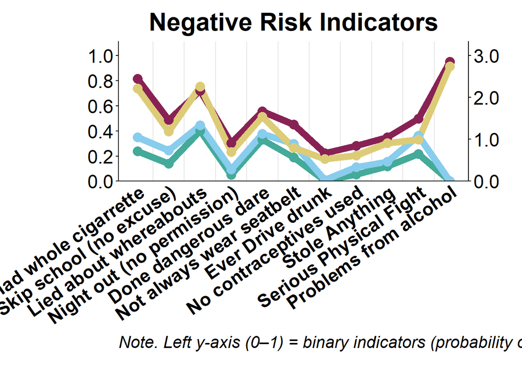

Figure 4

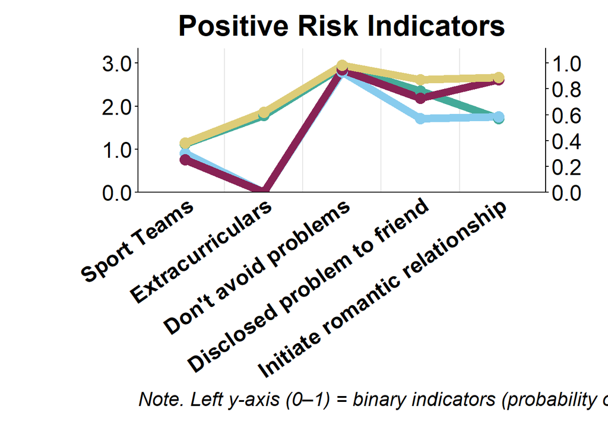

Figure 5

```r
fig_caption_line <- paste(
  "Note. Left y-axis (0\u20131) = binary indicators (probability of behavior).",
  "Right y-axis (0\u20133) = continuous indicators (within-class mean).",
  "Continuous values are rescaled to the primary axis for display;"
)

make_panel_line <- function(risk_label,
                            left_name  = "", left_lim, left_breaks,
                            sec_transform, right_name = "", right_breaks) {
  df_line <- profile_long %>% filter(Risk == risk_label)
  ggplot(df_line, aes(x = Indicators, y = value_plot,
                      color = cluster, group = cluster)) +
 geom_vline(
  xintercept = seq(1.5, length(unique(df_line$Indicators)) - 0.5, by = 1),
  color      = "gray90",
  linewidth  = 0.4
) +
    geom_line(linewidth = 3) +
    geom_point(size = 4) +
    scale_color_manual(values = indicator_colors, labels = cluster_labels,
                       name = NULL) +
    scale_y_continuous(
      limits = left_lim,
      breaks = left_breaks,
      labels = number_format(accuracy = 0.1),
      expand = expansion(mult = c(0, 0.03)),
      sec.axis = sec_axis(
        transform = sec_transform,
        name      = right_name,
        breaks    = right_breaks,
        labels    = number_format(accuracy = 0.1)
      )
    ) +
    labs(title = paste(risk_label, "Risk Indicators"), y = NULL, caption = fig_caption_line) +
    base_theme +
    theme(
      axis.text.x        = element_text(angle = 35, hjust = 1,
                                        size = axis_text_size),
      axis.title.y.right = element_text(size = axis_title_size,
                                        color = "gray40"),
      legend.position    = "none",
      plot.title         = element_text(size = title_size, face = "bold",
                                        hjust = 0.5),
      plot.margin       = margin(12, 0, 20, 85)
    )
}

# Negative: left=binary(0-1), right=continuous(0-3)
p_line_neg <- make_panel_line(
  risk_label    = "Negative",
  left_lim      = c(0, 1.08),
  left_breaks   = seq(0, 1, by = 0.2),
  sec_transform = ~ . * scale_factor,
  right_breaks  = seq(0, scale_factor, by = 1)
)

# Positive: left=continuous(0-3), right=binary(0-1)
p_line_pos <- make_panel_line(
  risk_label    = "Positive",
  left_lim      = c(0, scale_factor * 1.08),
  left_breaks   = seq(0, scale_factor, by = 1),
  sec_transform = ~ . / scale_factor,
  right_breaks  = seq(0, 1, by = 0.2)
)


print(p_line_neg)
ggsave(
  filename = file.path(fig_indicator, "profile_figure_line_neg.png"),
  device   = agg_png,
  plot     = p_line_neg,
  width    = 24, height = 8, dpi = fig_dpi, units = "in"
)

print(p_line_pos)
ggsave(
  filename = file.path(fig_indicator, "profile_figure_line_pos.png"),
  device   = agg_png,
  plot     = p_line_pos,
  width    = 24, height = 8, dpi = fig_dpi, units = "in"
)
```

[figure not shown]

```r
# Remove left axis from positive panel so the shared 0-3 middle axis appears only once
p_neg_trim_line <- p_line_neg +
  theme(
    axis.text.y.right = element_text(margin = margin(l = 12)),
    plot.margin       = margin(12, 0, 20, 85)
  )
p_pos_trim_line <- p_line_pos +
  theme(
    axis.title.y.left = element_blank(),
    axis.text.y.left  = element_blank(),
   # axis.ticks.y.left = element_blank(),
    plot.margin       = margin(12, 12, 12, 0)    # no left margin only
  )
combined_line <- (p_neg_trim_line + p_pos_trim_line) +
  plot_layout(guides = "collect") &
  theme(legend.position = "none")
combined_line
```

```r
ggsave(
  filename = file.path(fig_indicator, "profile_figures_combined_line.png"),
  plot     = combined_line,
  width    = 24, height = 14, dpi = fig_dpi, units = "in"
)
```

Back to top